[figure not shown]

```python
# PyParis logo
from IPython.display import Image
Image("PyParis.png")
```

# Introduction to Data Analysis using Python - PyParis 2017

### Francis Wolinski - Yotta Conseil

**Expertise & IT Audit - Data Science - Python**

- twitter: https://twitter.com/@fran6wol
- web: https://yotta-conseil.fr
- github : https://github.com/fran6w/PyParis2017

## 0. Tutorial objectives and materials

### 0.1 Objectives

- Exploring basic functionalities of Python Data Analysis Ecosystem: Numpy, Pandas, Matplotlib
- Analysis two different datasets but conforming them so that the same analysis can be performed on both datasets
- Perform few cross analysis on both datasets

### 0.2 Materials

**Python 3.5+** : numpy, pandas, matplotlib

**Datasets** :

- Names from *US Social Security* from 1880 to 2016 : https://www.ssa.gov/oact/babynames/limits.html (National data)
  - 137 CSV files named *yobYYYY.txt*, without header
  - Within each file: name, gender (F or M), births (int)
  - No names when less that 5 occurences in a year
- Names from *French Insee* from 1900 to 2015 : https://www.insee.fr/fr/statistiques/2540004 (Fichier France)
  - 1 single TSV file: *nat2015.txt*, with header
  - In the file: gender (1 or 2), name, year, births (float!)
  - No names when less than 3 occurences in a year
  - Rare names are labelled as *_PRENOMS_RARES*
  - Years for rare names are labelled *XXXX*

**References**

- Wes McKinney - Python for Data Analysis - O'Reilly (2013)
- Jake VanderPlas - Python Data Science Handbook - O'Reilly (2016)

```python
# imports
import numpy as np
import pandas as pd
import matplotlib.pyplot as plt

import os

# magic command to display graphics within the notebook
%matplotlib inline

# display options
from pandas import set_option
set_option("display.max_rows", 16)
set_option("precision", 3)
plt.style.use('seaborn-notebook')
```

## 1. Loading Data in a DataFrame

### 1.1 Loading US Data

#### 1.1.1 Loading a single file

We first load a single CSV file using Pandas' *read_csv()* function.

```python
# loads US data from last year
path = "datasets/names/"
filename = "yob2016.txt"
us2016 = pd.read_csv(os.path.join(path, filename),
                           header=None,
                           names=['name', 'gender', 'births'])
us2016
```

|  | name | gender | births |
| --- | --- | --- | --- |
| 0 | Emma | F | 19414 |
| 1 | Olivia | F | 19246 |
| 2 | Ava | F | 16237 |
| 3 | Sophia | F | 16070 |
| 4 | Isabella | F | 14722 |
| 5 | Mia | F | 14366 |
| 6 | Charlotte | F | 13030 |
| 7 | Abigail | F | 11699 |
| ... | ... | ... | ... |
| 32860 | Ziya | M | 5 |
| 32861 | Ziyang | M | 5 |
| 32862 | Zoel | M | 5 |
| 32863 | Zolton | M | 5 |
| 32864 | Zurich | M | 5 |
| 32865 | Zyahir | M | 5 |
| 32866 | Zyel | M | 5 |
| 32867 | Zylyn | M | 5 |

32868 rows × 3 columns

We obtain a Pandas DataFrame object which represents 2D data. The *info()* method provides the main characteritics of the DataFrame.

```python
# characteristics of a DataFrame
us2016.info()
```

```
<class 'pandas.core.frame.DataFrame'>
RangeIndex: 32868 entries, 0 to 32867
Data columns (total 3 columns):
name      32868 non-null object
gender    32868 non-null object
births    32868 non-null int64
dtypes: int64(1), object(2)
memory usage: 770.4+ KB
```

```python
# access to the index
us2016.index
```

```
RangeIndex(start=0, stop=32868, step=1)
```

```python
# acces to columns
us2016.columns
```

```
Index(['name', 'gender', 'births'], dtype='object')
```

```python
# acces to dimensions
us2016.shape
```

```
(32868, 3)
```

We can access to a specific column by using the *[]* operator and obtain a Pandas Series object which represents 1D data. It shares the original DataFrame index.

```python
# access to a specific column
us2016['name']  # us2016.name
```

```
0             Emma
1           Olivia
2              Ava
3           Sophia
4         Isabella
5              Mia
6        Charlotte
7          Abigail
           ...
32860         Ziya
32861       Ziyang
32862         Zoel
32863       Zolton
32864       Zurich
32865       Zyahir
32866         Zyel
32867        Zylyn
Name: name, dtype: object
```

```python
# number of US unique names
us2016['name'].nunique()
```

```
30294
```

**Few operations on DataFrame: transposition, sorting and grouping**

Transposition reverse rows and columns and switch index and column labels : *transpose()* or *T* method.

```python
# transposition T or transpose()
us2016.T
```

|  | 0 | 1 | 2 | 3 | 4 | 5 | 6 | 7 | 8 | 9 | ... | 32858 | 32859 | 32860 | 32861 | 32862 | 32863 | 32864 | 32865 | 32866 | 32867 |
| --- | --- | --- | --- | --- | --- | --- | --- | --- | --- | --- | --- | --- | --- | --- | --- | --- | --- | --- | --- | --- | --- |
| name | Emma | Olivia | Ava | Sophia | Isabella | Mia | Charlotte | Abigail | Emily | Harper | ... | Zinn | Zirui | Ziya | Ziyang | Zoel | Zolton | Zurich | Zyahir | Zyel | Zylyn |
| gender | F | F | F | F | F | F | F | F | F | F | ... | M | M | M | M | M | M | M | M | M | M |
| births | 19414 | 19246 | 16237 | 16070 | 14722 | 14366 | 13030 | 11699 | 10926 | 10733 | ... | 5 | 5 | 5 | 5 | 5 | 5 | 5 | 5 | 5 | 5 |

3 rows × 32868 columns

It is possible to sort a DataFrame by one or more columns and specifying the ascending : *sort_values()* method.

```python
# top 10 US names in 2016
us2016.sort_values('births', ascending=False).head(10)
```

|  | name | gender | births |
| --- | --- | --- | --- |
| 0 | Emma | F | 19414 |
| 1 | Olivia | F | 19246 |
| 18757 | Noah | M | 19015 |
| 18758 | Liam | M | 18138 |
| 2 | Ava | F | 16237 |
| 3 | Sophia | F | 16070 |
| 18759 | William | M | 15668 |
| 18760 | Mason | M | 15192 |
| 18761 | James | M | 14776 |
| 4 | Isabella | F | 14722 |

DataFrame are provided with a powerful *groupby()* method which splits it into chuncks - according to the values of one or more columns - and then apply a summarization function to each chunk and concatenates the whole in a new DataFrame.

This illustrates the *split-apply-combine* strategy : *groupby()* then *sum()* methods.

```python
# US female and male births of year 2016
us2016.groupby('gender').sum()
```

| gender | births |
| --- | --- |
| F | 1756647 |
| M | 1880674 |

#### 1.1.2 Loading all files

We load and merge all CSV files within the folder *names*. The year is extracted from file names and added as a new column. We use the *append()* method which concatenates 2 DataFrames.

```python
# load all data in a single DataFrame
us = pd.DataFrame()
for root, dirs, files in os.walk(path):
    for filename in files:
        if filename[0:3] != "yob":
            continue
        csv = pd.read_csv(os.path.join(root, filename),
                           header=None,
                           names=['name', 'gender', 'births'])
        year = int(filename[3:7])  # yobYYYY.txt
        csv['year'] = year
        us = us.append(csv, ignore_index=True)

us = us[['year', 'name', 'gender', 'births']]  # fancy indexing in order to reorder the columns

us
```

|  | year | name | gender | births |
| --- | --- | --- | --- | --- |
| 0 | 1880 | Mary | F | 7065 |
| 1 | 1880 | Anna | F | 2604 |
| 2 | 1880 | Emma | F | 2003 |
| 3 | 1880 | Elizabeth | F | 1939 |
| 4 | 1880 | Minnie | F | 1746 |
| 5 | 1880 | Margaret | F | 1578 |
| 6 | 1880 | Ida | F | 1472 |
| 7 | 1880 | Alice | F | 1414 |
| ... | ... | ... | ... | ... |
| 1891886 | 2016 | Ziya | M | 5 |
| 1891887 | 2016 | Ziyang | M | 5 |
| 1891888 | 2016 | Zoel | M | 5 |
| 1891889 | 2016 | Zolton | M | 5 |
| 1891890 | 2016 | Zurich | M | 5 |
| 1891891 | 2016 | Zyahir | M | 5 |
| 1891892 | 2016 | Zyel | M | 5 |
| 1891893 | 2016 | Zylyn | M | 5 |

1891894 rows × 4 columns

```python
# characteristics of a DataFrame
us.info()
```

```
<class 'pandas.core.frame.DataFrame'>
RangeIndex: 1891894 entries, 0 to 1891893
Data columns (total 4 columns):
year      int64
name      object
gender    object
births    int64
dtypes: int64(2), object(2)
memory usage: 57.7+ MB
```

```python
# number of US unique names
us['name'].nunique()
```

```
96174
```

```python
# top 10 global US names within a year
us.sort_values('births', ascending=False).head(10)
```

|  | year | name | gender | births |
| --- | --- | --- | --- | --- |
| 431059 | 1947 | Linda | F | 99685 |
| 441430 | 1948 | Linda | F | 96210 |
| 437162 | 1947 | James | M | 94762 |
| 544612 | 1957 | Michael | M | 92716 |
| 437163 | 1947 | Robert | M | 91641 |
| 451669 | 1949 | Linda | F | 91013 |
| 533150 | 1956 | Michael | M | 90620 |
| 556187 | 1958 | Michael | M | 90512 |
| 447469 | 1948 | James | M | 88584 |
| 510799 | 1954 | Michael | M | 88525 |

```python
# global US female and male births
us.groupby('gender').sum()  # ['births']  # [['births']]
```

| gender | year | births |
| --- | --- | --- |
| F | 2211413526 | 170639571 |
| M | 1523416826 | 173894326 |

What are the top 10 US names all years? We are going to implement a function so that it can be reused later.

```python
# top (10) names all years
def top(df, size=10):
    return df.groupby(['name', 'gender']).sum()['births'].sort_values(ascending=False).head(size)
```

```python
# global US top 10 names all years
top(us)
```

```
name     gender
James    M         5136026
John     M         5105834
Robert   M         4809176
Michael  M         4338144
Mary     F         4120692
William  M         4087525
David    M         3601032
Joseph   M         2592856
Richard  M         2560771
Charles  M         2378806
Name: births, dtype: int64
```

### 1.2 Loading French Data

Firstly, we load the French data in order to have a look at them.

```python
# load
fr = pd.read_csv("datasets/nat2015.txt",
                     sep='\t',
                     encoding='latin-1',
                     header=0,
                     names = ['gender', 'name', 'year', 'births'])
fr = fr[['year', 'name', 'gender', 'births']]
fr
```

|  | year | name | gender | births |
| --- | --- | --- | --- | --- |
| 0 | 1980 | A | 1 | 3.0 |
| 1 | 1998 | A | 1 | 3.0 |
| 2 | XXXX | A | 1 | 21.0 |
| 3 | 1976 | AADEL | 1 | 5.0 |
| 4 | 1978 | AADEL | 1 | 3.0 |
| 5 | 1980 | AADEL | 1 | 3.0 |
| 6 | 1981 | AADEL | 1 | 5.0 |
| 7 | 1982 | AADEL | 1 | 4.0 |
| ... | ... | ... | ... | ... |
| 589403 | 1992 | ÖZLEM | 2 | 5.0 |
| 589404 | 1993 | ÖZLEM | 2 | 7.0 |
| 589405 | 2010 | ÖZLEM | 2 | 3.0 |
| 589406 | 2012 | ÖZLEM | 2 | 6.0 |
| 589407 | 2013 | ÖZLEM | 2 | 3.0 |
| 589408 | 2014 | ÖZLEM | 2 | 5.0 |
| 589409 | 2015 | ÖZLEM | 2 | 3.0 |
| 589410 | XXXX | ÖZLEM | 2 | 25.0 |

589411 rows × 4 columns

Secondly, we reload the French data so that they have the same characteristics as the US ones :

- columns :
  - gender mapping '1' => 'M', '2' => 'F' and switching to caterogy
  - name case including compound names with '-'
  - year astype int
  - births astype int
- eliminate irrelevant data
- sort the data
- reset the index

```python
# load French data
fr = pd.read_csv("datasets/nat2015.txt",
                     sep='\t',
                     encoding='latin-1',
                     header=0,
                     names = ['gender', 'name', 'year', 'births'],
                     converters = {'gender': lambda x: 'M' if x == '1' else 'F',
                                   'name': lambda x: '-'.join(map(lambda y: y.capitalize(), x.split('-'))),
                                   'births': lambda x: int(float(x))})
fr = fr[(fr['year'] != 'XXXX') &
              (fr['name'] != '_prenoms_rares') &
              (fr['name'].str.len() != 1)]
fr['year'] = fr['year'].astype(int)
fr = fr[['year', 'name', 'gender', 'births']]
fr.sort_values(['year', 'gender', 'births', 'name'], ascending=[True, True, False, True], inplace=True)
fr.reset_index(drop=True, inplace=True)
fr
```

|  | year | name | gender | births |
| --- | --- | --- | --- | --- |
| 0 | 1900 | Marie | F | 48727 |
| 1 | 1900 | Jeanne | F | 13983 |
| 2 | 1900 | Marguerite | F | 8059 |
| 3 | 1900 | Germaine | F | 6981 |
| 4 | 1900 | Louise | F | 6698 |
| 5 | 1900 | Yvonne | F | 5099 |
| 6 | 1900 | Madeleine | F | 4960 |
| 7 | 1900 | Suzanne | F | 4954 |
| ... | ... | ... | ... | ... |
| 556735 | 2015 | Zayad | M | 3 |
| 556736 | 2015 | Zayane | M | 3 |
| 556737 | 2015 | Ziggy | M | 3 |
| 556738 | 2015 | Zoan | M | 3 |
| 556739 | 2015 | Zoubir | M | 3 |
| 556740 | 2015 | Zoé | M | 3 |
| 556741 | 2015 | Étan | M | 3 |
| 556742 | 2015 | Évann | M | 3 |

556743 rows × 4 columns

```python
# characteristics of a DataFrame
fr.info()
```

```
<class 'pandas.core.frame.DataFrame'>
RangeIndex: 556743 entries, 0 to 556742
Data columns (total 4 columns):
year      556743 non-null int32
name      556743 non-null object
gender    556743 non-null object
births    556743 non-null int64
dtypes: int32(1), int64(1), object(2)
memory usage: 14.9+ MB
```

```python
# top 10 global French names within a year
fr.sort_values('births', ascending=False).head(10)
```

|  | year | name | gender | births |
| --- | --- | --- | --- | --- |
| 95476 | 1946 | Jean | M | 53897 |
| 1705 | 1901 | Marie | F | 52167 |
| 3434 | 1902 | Marie | F | 51870 |
| 97892 | 1947 | Jean | M | 51665 |
| 5174 | 1903 | Marie | F | 50445 |
| 6931 | 1904 | Marie | F | 50153 |
| 8709 | 1905 | Marie | F | 48998 |
| 0 | 1900 | Marie | F | 48727 |
| 10545 | 1906 | Marie | F | 48465 |
| 14232 | 1908 | Marie | F | 47479 |

```python
# global French female and male births
fr.groupby('gender').sum()['births']
```

```
gender
F    39990411
M    40680898
Name: births, dtype: int64
```

```python
# global French top 10 names all years
top(fr)
```

```
name      gender
Marie     F         2234906
Jean      M         1919820
Pierre    M          889306
Michel    M          820080
André     M          711757
Jeanne    F          550384
Philippe  M          538133
René      M          516492
Alain     M          506750
Louis     M          504437
Name: births, dtype: int64
```

## 2. Searching in the Data

### 2.1 Two letters names

We are going to implement a function that looks for names with only 2 letters. We use the *str* operator which tells Python to process series data as strings. Then we use the *[]* operator for a logical selection.

```python
# making a boolean mask
mask = us['name'].str.len() == 2
mask
```

```
0          False
1          False
2          False
3          False
4          False
5          False
6          False
7          False
           ...
1891886    False
1891887    False
1891888    False
1891889    False
1891890    False
1891891    False
1891892    False
1891893    False
Name: name, dtype: bool
```

```python
# using the mask to select data
us[mask]
```

|  | year | name | gender | births |
| --- | --- | --- | --- | --- |
| 996 | 1880 | Ed | M | 310 |
| 1444 | 1880 | Wm | M | 14 |
| 1467 | 1880 | Al | M | 12 |
| 1850 | 1880 | Ab | M | 5 |
| 2880 | 1881 | Jo | F | 5 |
| 2998 | 1881 | Ed | M | 272 |
| 3326 | 1881 | Al | M | 19 |
| 3396 | 1881 | Wm | M | 15 |
| ... | ... | ... | ... | ... |
| 1889035 | 2016 | Jb | M | 6 |
| 1889463 | 2016 | Or | M | 6 |
| 1889871 | 2016 | Zi | M | 6 |
| 1889875 | 2016 | Zo | M | 6 |
| 1890122 | 2016 | Bb | M | 5 |
| 1890482 | 2016 | En | M | 5 |
| 1891392 | 2016 | Qi | M | 5 |
| 1891817 | 2016 | Ye | M | 5 |

4588 rows × 4 columns

We implement a function which perform all necessary operations and run US and French data using the *unique()* method.

```python
# searching for names with 2 letters only
def names_of_length_2(df):
    mask = df['name'].str.len() == 2
    return df[mask]['name'].unique()
```

```python
# US names with 2 letters
names_of_length_2(us)
```

```
array(['Ed', 'Wm', 'Al', 'Ab', 'Jo', 'Ah', 'Ng', 'Lu', 'Le', 'Ad', 'Cy',
       'Bo', 'Mc', 'La', 'Jc', 'Hy', 'Jb', 'De', 'Jd', 'Jt', 'El', 'Jr',
       'Ty', 'Vi', 'Ac', 'Sy', 'Lc', 'Od', 'Tj', 'Wc', 'Ld', 'Rc', 'Jw',
       'Be', 'Eb', 'Jl', 'St', 'Lo', 'Oc', 'Rb', 'Lj', 'Lb', 'Rl', 'Rd',
       'Hu', 'Lg', 'Av', 'Ma', 'Ej', 'Si', 'Su', 'Ok', 'An', 'Di', 'Ki',
       'Ky', 'Li', 'Ea', 'Mi', 'In', 'Ja', 'Zo', 'Fe', 'Aj', 'Kc', 'Ka',
       'Jj', 'Dj', 'Bj', 'Gy', 'Je', 'Ji', 'Cj', 'Ra', 'Yu', 'Pj', 'Ta',
       'My', 'Ry', 'Ho', 'Ly', 'Na', 'Rj', 'Ai', 'Tu', 'Vu', 'Ha', 'Ti',
       'Un', 'Jm', 'Pa', 'Ju', 'So', 'Vy', 'Jp', 'Ia', 'Yi', 'Du', 'Ge',
       'Va', 'Sa', 'Wa', 'Po', 'Tc', 'Ni', 'Da', 'Fu', 'Om', 'Ya', 'Me',
       'Ko', 'Ku', 'Se', 'Gi', 'Xu', 'Kt', 'Ye', 'Kd', 'Te', 'Do', 'Md',
       'Kj', 'Ii', 'Mr', 'Bg', 'No', 'Bb', 'Ke', 'Oz', 'Ze', 'Io', 'Qi',
       'Zi', 'Ny', 'Zy', 'Mj', 'Yo', 'Eh', 'Or', 'En', 'Za', 'Sj', 'Ar',
       'Ro', 'Mo', 'Oh', 'Xi', 'Tr'], dtype=object)
```

```python
# French names with 2 letters
names_of_length_2(fr)
```

```
array(['St', 'Ah', 'Jo', 'El', 'Ab', 'Si', 'Le', 'Ha', 'My', 'Al', 'Da',
       'An', 'Ly', 'Pa', 'Va', 'Ai', 'Yi', 'By', 'Tu', 'Ka', 'Ma', 'Yu',
       'Na', 'So', 'Ya', 'Vu', 'Ky', 'Lu', 'Li', 'Vi', 'To', 'Ba', 'Sy',
       'Su', 'Do', 'Ea', 'De', 'Ny', 'Mc', 'Or', 'Ty', 'La', 'Bo', 'Zi',
       'Bi'], dtype=object)
```

### 2.2 Names for which births = year

Now, we implement a function which looks for names for which births within a year are equal to the year.

```python
# looking for names for wich births within a year are equal to the year
def births_is_year(df):
    return df[df['births'] == df['year']]
```

```python
# US names with births equals year
births_is_year(us)
```

|  | year | name | gender | births |
| --- | --- | --- | --- | --- |
| 76786 | 1907 | Minnie | F | 1907 |
| 134324 | 1916 | Oscar | M | 1916 |
| 265125 | 1929 | Velma | F | 1929 |
| 274940 | 1930 | Janice | F | 1930 |
| 312410 | 1934 | Agnes | F | 1934 |
| 371429 | 1940 | Vernon | M | 1940 |
| 421493 | 1946 | Margie | F | 1946 |
| 544774 | 1957 | Gilbert | M | 1957 |
| 1249432 | 1997 | Selena | F | 1997 |
| 1293009 | 1998 | Gage | M | 1998 |
| 1692050 | 2011 | Eliana | F | 2011 |
| 1745461 | 2012 | Avery | M | 2012 |
| 1859178 | 2016 | Norah | F | 2016 |
| 1859179 | 2016 | Rose | F | 2016 |

```python
# French names with briths equals year
births_is_year(fr)
```

|  | year | name | gender | births |
| --- | --- | --- | --- | --- |
| 3461 | 1902 | Angèle | F | 1902 |
| 23212 | 1912 | Marius | M | 1912 |
| 55913 | 1928 | Gaston | M | 1928 |
| 68050 | 1933 | Fernand | M | 1933 |
| 466147 | 2009 | Lou | F | 2009 |

### 2.3 Looking for prefix

Here, we implement a function which search for prefix names.

First, we select the names starting with a specific prefix using the *str* operator and the *startswith()* method.

```python
# select US names starting with 'Fran'
selection = us[us['name'].str.startswith("Fran")]
selection
```

|  | year | name | gender | births |
| --- | --- | --- | --- | --- |
| 41 | 1880 | Frances | F | 605 |
| 205 | 1880 | Francis | F | 55 |
| 410 | 1880 | Frankie | F | 17 |
| 478 | 1880 | Frank | F | 13 |
| 947 | 1880 | Frank | M | 3242 |
| 991 | 1880 | Francis | M | 344 |
| 1053 | 1880 | Franklin | M | 120 |
| 1336 | 1880 | Francisco | M | 19 |
| ... | ... | ... | ... | ... |
| 1882584 | 2016 | Franz | M | 20 |
| 1882939 | 2016 | Fransisco | M | 18 |
| 1883613 | 2016 | Francois | M | 15 |
| 1886094 | 2016 | Franciszek | M | 9 |
| 1887714 | 2016 | Fran | M | 7 |
| 1890537 | 2016 | Frances | M | 5 |
| 1890538 | 2016 | Franck | M | 5 |
| 1890539 | 2016 | Frandy | M | 5 |

4705 rows × 4 columns

Second, we can reuse the top function and implement a new function.

```python
# looking for prefix
def look(df, prefix, **kwargs):
    selection = df[df['name'].str.startswith(prefix)]
    return top(selection, **kwargs)
```

```python
# US names starting with "Fran"
look(us, "Fran")
```

```
name       gender
Frank      M         909430
Frances    F         588601
Francis    M         284528
Franklin   M         134707
Francisco  M         131432
Frankie    M          40310
Francine   F          35747
Frankie    F          32913
Francis    F          29041
Francesca  F          28176
Name: births, dtype: int64
```

```python
# French names starting with "Fran"
look(fr, "Fran")
```

```
name             gender
Françoise        F         401522
François         M         398241
Franck           M         177720
Francis          M         166060
Francine         F          92723
France           F          28073
Frank            M          11379
Francette        F           7777
Francisco        M           7236
François-Xavier  M           7125
Name: births, dtype: int64
```

We can see a French compound name. What are the top French compound name?

```python
# global French top 10 compound names all years
selection = fr[fr['name'].str.contains('-')]
top(selection)
```

```
name           gender
Jean-Pierre    M         213143
Jean-Claude    M         172142
Jean-Luc       M         116647
Anne-Marie     F          99695
Jean-François  M          99024
Jean-Marc      M          90144
Marie-Thérèse  F          88345
Jean-Paul      M          86843
Jean-Marie     M          86223
Jean-Michel    M          85960
Name: births, dtype: int64
```

## 3. Putting Data into Graphs

### 3.1 Evolution of births for a single name (+ gender) over years

First, we select the data according to a name (Kevin) and a gender (M). Logical operators (&, | and ~) are provided for selecting data.

```python
# selection of data related to Kevin (M)
selection = us[(us['name'] == "Kevin") & (us['gender'] == "M")]
selection
```

|  | year | name | gender | births |
| --- | --- | --- | --- | --- |
| 103699 | 1912 | Kevin | M | 9 |
| 110513 | 1913 | Kevin | M | 9 |
| 117875 | 1914 | Kevin | M | 12 |
| 126616 | 1915 | Kevin | M | 15 |
| 135970 | 1916 | Kevin | M | 18 |
| 145816 | 1917 | Kevin | M | 19 |
| 155956 | 1918 | Kevin | M | 21 |
| 166850 | 1919 | Kevin | M | 14 |
| ... | ... | ... | ... | ... |
| 1643354 | 2009 | Kevin | M | 8767 |
| 1677700 | 2010 | Kevin | M | 7322 |
| 1711516 | 2011 | Kevin | M | 6558 |
| 1745343 | 2012 | Kevin | M | 6216 |
| 1778794 | 2013 | Kevin | M | 5929 |
| 1811995 | 2014 | Kevin | M | 5886 |
| 1845095 | 2015 | Kevin | M | 5164 |
| 1877871 | 2016 | Kevin | M | 4526 |

105 rows × 4 columns

Second, we switch the year column to be the index of the DataFrame.

```python
# same with year as index
selection_years = selection.set_index('year')
selection_years
```

| year | name | gender | births |
| --- | --- | --- | --- |
| 1912 | Kevin | M | 9 |
| 1913 | Kevin | M | 9 |
| 1914 | Kevin | M | 12 |
| 1915 | Kevin | M | 15 |
| 1916 | Kevin | M | 18 |
| 1917 | Kevin | M | 19 |
| 1918 | Kevin | M | 21 |
| 1919 | Kevin | M | 14 |
| ... | ... | ... | ... |
| 2009 | Kevin | M | 8767 |
| 2010 | Kevin | M | 7322 |
| 2011 | Kevin | M | 6558 |
| 2012 | Kevin | M | 6216 |
| 2013 | Kevin | M | 5929 |
| 2014 | Kevin | M | 5886 |
| 2015 | Kevin | M | 5164 |
| 2016 | Kevin | M | 4526 |

105 rows × 3 columns

There is a strong connexion between Pandas DataFrame and Matplotlib. We can directly use the Matplotlib *plot()* function which applied to DataFrame or Series as a method.

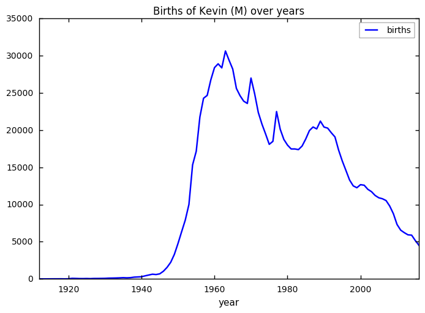

```python
# plot the births column along with the years
selection_years.plot(title="Births of Kevin (M) over years");
```

We can put every thing together in a single function and run the French data.

```python
# evolution of a name (+ gender)
def plot_name_gender(df, name, gender):
    selection = df[(df['name'] == name) & (df['gender'] == gender)]
    selection_years = selection.set_index('year')
    selection_years.plot(title="Births of {} ({}) over years".format(name, gender));
```

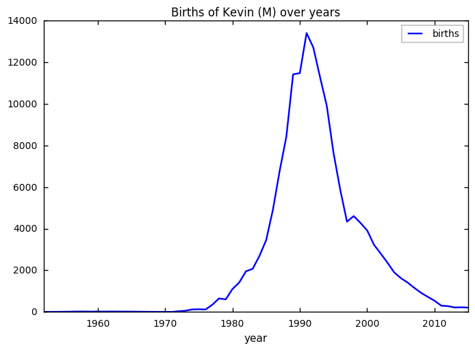

```python
# evolution of French Kevin (M)
plot_name_gender(fr, 'Kevin', 'M')
```

We will try to find later correlations between US and French names over time.

### 3.2 Evolution of births by gender over years

DataFrame are provided with another powerful method *pivot_table()*. It produces a new DataFrame with as the index the different values of a first column, as the column index the different values of second column and the values of a third column are summarized into cells by using an aggregative function.

We use here this method to obtain the births by gender over years.

```python
# pivoting US data by years and gender and computing the sum of births
genders = us.pivot_table(index='year',
                         columns='gender',
                         values='births',
                         aggfunc=np.sum)
genders
```

| gender year | F | M |
| --- | --- | --- |
| 1880 | 90992 | 110491 |
| 1881 | 91953 | 100743 |
| 1882 | 107847 | 113686 |
| 1883 | 112318 | 104627 |
| 1884 | 129020 | 114443 |
| 1885 | 133055 | 107799 |
| 1886 | 144533 | 110784 |
| 1887 | 145981 | 101415 |
| ... | ... | ... |
| 2009 | 1834048 | 1980491 |
| 2010 | 1774186 | 1915331 |
| 2011 | 1755278 | 1895156 |
| 2012 | 1756347 | 1892094 |
| 2013 | 1749061 | 1885683 |
| 2014 | 1779496 | 1913434 |
| 2015 | 1776538 | 1907211 |
| 2016 | 1756647 | 1880674 |

137 rows × 2 columns

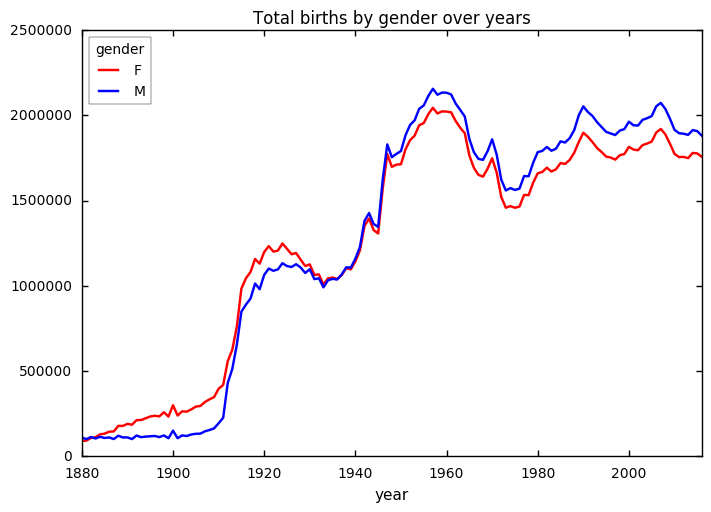

```python
# plot number of births by gender over years
genders.plot(title="Total births by gender over years", color=['r', 'b']);
```

We can put every thing together in a single function and run the French data.

```python
# plot number of births by gender over years
def plot_births(df):
    table = df.pivot_table(index='year',
                           columns='gender',
                           values='births',
                           aggfunc=np.sum)
    table.plot(title="Total births by gender over years", color=['r', 'b']);
```

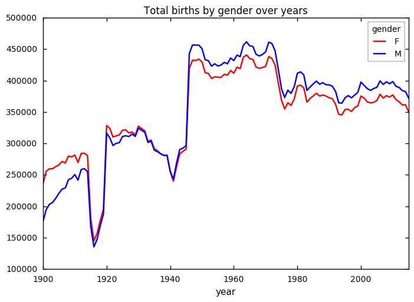

```python
# plot French births by gender over years
plot_births(fr)
```

## 4. Measuring the increase in naming diversity

We are using the *crosstab()* method in order to compute the number of different names by gender over years. In the 1880' parents had roughly 1000 names per gender to name their babies. Nowadays, parents have 14 to 19 thousands!

```python
# number of different names by gender over years
diversity = pd.crosstab(us['year'], us['gender'])
diversity.head()
```

| gender year | F | M |
| --- | --- | --- |
| 1880 | 942 | 1058 |
| 1881 | 938 | 997 |
| 1882 | 1028 | 1099 |
| 1883 | 1054 | 1030 |
| 1884 | 1172 | 1125 |

```python
# nowadays
diversity.tail()
```

| gender year | F | M |
| --- | --- | --- |
| 2012 | 19486 | 14229 |
| 2013 | 19219 | 14034 |
| 2014 | 19169 | 14037 |
| 2015 | 19054 | 14009 |
| 2016 | 18757 | 14111 |

We can put every thing together in a single function.

```python
# plot evolution of number of names over years
def plot_diversity(df):
    diversity = pd.crosstab(df['year'], df['gender'])
    diversity.plot(title="Evolution of names diversity by gender over years", color=['r', 'b']);
```

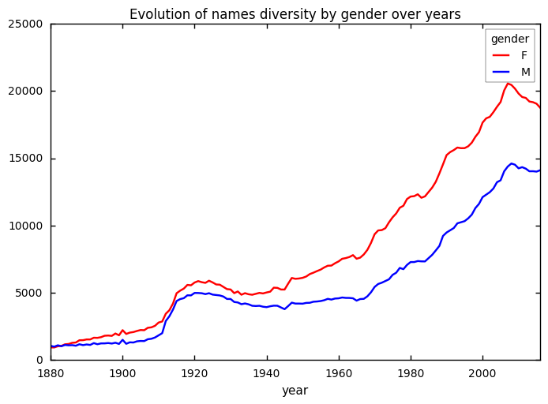

```python
# US diversity
plot_diversity(us)
```

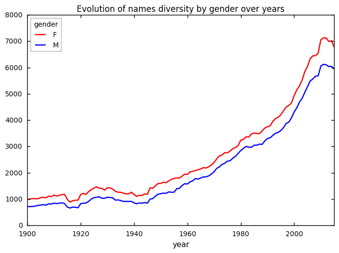

```python
# French diversity
plot_diversity(fr)
```

## 5. Evolution of Last Letter

We will now add a column with the last letter of each name and compute the evolution of the most frequent last letters which appears nowadays. This is computed by using the *apply()* method and a *lambda* function which extracts the last letter and put it in uppercase for readability.

```python
# add a column with the last later of names
us["last"] = us["name"].apply(lambda x: x[-1].upper())
us
```

|  | year | name | gender | births | last |
| --- | --- | --- | --- | --- | --- |
| 0 | 1880 | Mary | F | 7065 | Y |
| 1 | 1880 | Anna | F | 2604 | A |
| 2 | 1880 | Emma | F | 2003 | A |
| 3 | 1880 | Elizabeth | F | 1939 | H |
| 4 | 1880 | Minnie | F | 1746 | E |
| 5 | 1880 | Margaret | F | 1578 | T |
| 6 | 1880 | Ida | F | 1472 | A |
| 7 | 1880 | Alice | F | 1414 | E |
| ... | ... | ... | ... | ... | ... |
| 1891886 | 2016 | Ziya | M | 5 | A |
| 1891887 | 2016 | Ziyang | M | 5 | G |
| 1891888 | 2016 | Zoel | M | 5 | L |
| 1891889 | 2016 | Zolton | M | 5 | N |
| 1891890 | 2016 | Zurich | M | 5 | H |
| 1891891 | 2016 | Zyahir | M | 5 | R |
| 1891892 | 2016 | Zyel | M | 5 | L |
| 1891893 | 2016 | Zylyn | M | 5 | N |

1891894 rows × 5 columns

```python
# diversity of names by last letter over years
last = pd.crosstab(us['year'], us['last'])
last
```

| last year | A | B | C | D | E | F | G | H | I | J | ... | Q | R | S | T | U | V | W | X | Y | Z |
| --- | --- | --- | --- | --- | --- | --- | --- | --- | --- | --- | --- | --- | --- | --- | --- | --- | --- | --- | --- | --- | --- |
| 1880 | 450 | 7 | 7 | 93 | 490 | 7 | 9 | 60 | 7 | 0 | ... | 0 | 89 | 125 | 76 | 5 | 1 | 7 | 4 | 148 | 4 |
| 1881 | 432 | 6 | 8 | 85 | 484 | 5 | 13 | 59 | 6 | 0 | ... | 0 | 83 | 116 | 78 | 4 | 1 | 7 | 5 | 142 | 2 |
| 1882 | 478 | 7 | 8 | 96 | 538 | 8 | 10 | 70 | 6 | 0 | ... | 0 | 87 | 124 | 83 | 3 | 1 | 8 | 5 | 167 | 4 |
| 1883 | 480 | 5 | 8 | 96 | 542 | 7 | 10 | 61 | 4 | 0 | ... | 0 | 86 | 122 | 79 | 4 | 1 | 9 | 6 | 151 | 2 |
| 1884 | 543 | 10 | 7 | 101 | 584 | 6 | 10 | 72 | 4 | 0 | ... | 0 | 100 | 133 | 83 | 4 | 1 | 7 | 4 | 179 | 4 |
| 1885 | 547 | 8 | 8 | 88 | 614 | 6 | 12 | 69 | 6 | 0 | ... | 0 | 95 | 130 | 83 | 3 | 1 | 6 | 5 | 174 | 2 |
| 1886 | 583 | 7 | 7 | 103 | 633 | 4 | 12 | 72 | 5 | 0 | ... | 0 | 96 | 127 | 87 | 4 | 1 | 7 | 4 | 188 | 3 |
| 1887 | 591 | 8 | 8 | 105 | 633 | 6 | 8 | 73 | 6 | 0 | ... | 0 | 102 | 121 | 81 | 4 | 1 | 7 | 4 | 173 | 4 |
| ... | ... | ... | ... | ... | ... | ... | ... | ... | ... | ... | ... | ... | ... | ... | ... | ... | ... | ... | ... | ... | ... |
| 2009 | 7975 | 124 | 117 | 496 | 4438 | 70 | 96 | 2610 | 2330 | 56 | ... | 23 | 1250 | 1222 | 480 | 135 | 67 | 47 | 105 | 2210 | 188 |
| 2010 | 7659 | 135 | 123 | 508 | 4345 | 75 | 103 | 2621 | 2310 | 68 | ... | 21 | 1244 | 1182 | 453 | 137 | 71 | 42 | 107 | 2192 | 178 |
| 2011 | 7399 | 127 | 105 | 501 | 4417 | 76 | 96 | 2613 | 2327 | 67 | ... | 24 | 1249 | 1171 | 452 | 151 | 70 | 50 | 116 | 2155 | 170 |
| 2012 | 7293 | 117 | 118 | 476 | 4364 | 76 | 111 | 2560 | 2402 | 70 | ... | 23 | 1282 | 1182 | 479 | 136 | 74 | 47 | 119 | 2168 | 172 |
| 2013 | 7150 | 124 | 110 | 502 | 4333 | 84 | 103 | 2550 | 2300 | 63 | ... | 22 | 1256 | 1156 | 471 | 154 | 77 | 47 | 132 | 2147 | 161 |
| 2014 | 7050 | 124 | 105 | 517 | 4262 | 74 | 102 | 2523 | 2286 | 69 | ... | 21 | 1302 | 1152 | 499 | 140 | 77 | 51 | 136 | 2130 | 170 |
| 2015 | 6982 | 114 | 114 | 513 | 4238 | 78 | 111 | 2513 | 2386 | 71 | ... | 28 | 1338 | 1167 | 486 | 152 | 90 | 47 | 151 | 2149 | 157 |
| 2016 | 6944 | 126 | 113 | 525 | 4073 | 77 | 122 | 2518 | 2385 | 72 | ... | 30 | 1391 | 1149 | 510 | 171 | 80 | 50 | 156 | 2081 | 153 |

137 rows × 26 columns

Then we sort the letters of the last available year. We use the *.iloc[]* operator which enables to select rows, columns and parts of a DataFrame by indices.

```python
# sort most used last letters for US names in 2015
last.iloc[-1].sort_values(ascending=False)
```

```
last
N    7015
A    6944
E    4073
H    2518
I    2385
Y    2081
R    1391
L    1350
     ...
G     122
C     113
V      80
F      77
J      72
W      50
P      31
Q      30
Name: 2016, dtype: int64
```

Here we put the 7 top letters in an array.

```python
# put the 7 letters in an array
letters = last.iloc[-1].sort_values(ascending=False).index[:7]
letters
```

```
Index(['N', 'A', 'E', 'H', 'I', 'Y', 'R'], dtype='object', name='last')
```

We can perform a fancy indexing on the DataFrame with the 7 letters and perform a plot.

```python
# last letters DataFrame limited to 7 top last letters of 2015
last[letters]
```

| last year | N | A | E | H | I | Y | R |
| --- | --- | --- | --- | --- | --- | --- | --- |
| 1880 | 223 | 450 | 490 | 60 | 7 | 148 | 89 |
| 1881 | 214 | 432 | 484 | 59 | 6 | 142 | 83 |
| 1882 | 224 | 478 | 538 | 70 | 6 | 167 | 87 |
| 1883 | 214 | 480 | 542 | 61 | 4 | 151 | 86 |
| 1884 | 244 | 543 | 584 | 72 | 4 | 179 | 100 |
| 1885 | 226 | 547 | 614 | 69 | 6 | 174 | 95 |
| 1886 | 240 | 583 | 633 | 72 | 5 | 188 | 96 |
| 1887 | 233 | 591 | 633 | 73 | 6 | 173 | 102 |
| ... | ... | ... | ... | ... | ... | ... | ... |
| 2009 | 7460 | 7975 | 4438 | 2610 | 2330 | 2210 | 1250 |
| 2010 | 7353 | 7659 | 4345 | 2621 | 2310 | 2192 | 1244 |
| 2011 | 7400 | 7399 | 4417 | 2613 | 2327 | 2155 | 1249 |
| 2012 | 7322 | 7293 | 4364 | 2560 | 2402 | 2168 | 1282 |
| 2013 | 7177 | 7150 | 4333 | 2550 | 2300 | 2147 | 1256 |
| 2014 | 7271 | 7050 | 4262 | 2523 | 2286 | 2130 | 1302 |
| 2015 | 7062 | 6982 | 4238 | 2513 | 2386 | 2149 | 1338 |
| 2016 | 7015 | 6944 | 4073 | 2518 | 2385 | 2081 | 1391 |

137 rows × 7 columns

We can put every thing together in a single function and run the French data.

```python
# plot the evolution of diversity of names according to their last letter
def plot_last_letters(df):
    df["last"] = df["name"].apply(lambda x: x[-1].upper())
    last = pd.crosstab(df['year'], df['last'])
    letters = last.iloc[-1].sort_values(ascending=False).head(7).index
    last[letters].plot(title="Evolution of diversity of names according to their last letter");
```

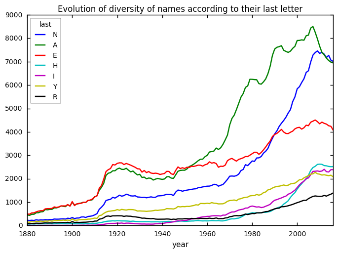

```python
# plot the evolution of diversity of US names according to their last letter
plot_last_letters(us)
```

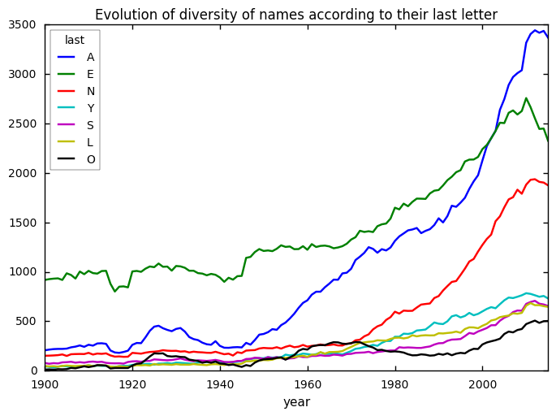

```python
# plot the evolution of diversity of US names according to their last letter
plot_last_letters(fr)
```

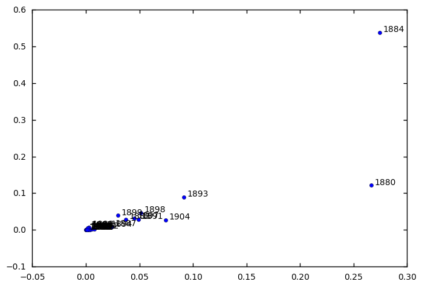

```python
# interactive scatter plot of last letters for US and French names across years
from ipywidgets import interact, IntSlider

# prepare and normalize data
last_us = pd.crosstab(us['year'], us['last'])
last_us = last_us.div(last_us.sum(axis=1), axis=0)
last_fr = pd.crosstab(fr['year'], fr['last'])
last_fr = last_fr.div(last_fr.sum(axis=1), axis=0)

def plot_letters(year):
    data = pd.concat([last_us.loc[year], last_fr.loc[year]], axis=1, join='inner')
    plt.scatter(data.iloc[:,0], data.iloc[:,1])
    for (x, y, letter) in zip(data.iloc[:,0], data.iloc[:,1], last.index):
        plt.text(x + 0.003, y + 0.003, letter)

interact(plot_letters, year=IntSlider(min=1900, max=2015, step=1, value=1900));
```

## 6. Names which gender changed over time

### 6.1 Global gender repartition per name

First we restrict names which appear at least 10000 times as F or M over time.

```python
# find top names
top_names = us.groupby('name').sum()['births']
top_names = top_names.sort_values(ascending=False)
top_names = top_names[top_names >= 10000]
top_names
```

```
name
James       5159306
John        5127501
Robert      4829274
Michael     4359820
Mary        4135851
William     4103456
David       3613916
Joseph      2603475
             ...
Kenna         10079
Jovan         10068
Tatyana       10061
Karly         10054
Catrina       10045
Randell       10031
Gilda         10022
Marisela      10012
Name: births, dtype: int64
```

Select those names in the US DataFrame using the *isin()* method.

```python
# data for top names
selection = us[us['name'].isin(top_names.index)]
selection
```

|  | year | name | gender | births | last |
| --- | --- | --- | --- | --- | --- |
| 0 | 1880 | Mary | F | 7065 | Y |
| 1 | 1880 | Anna | F | 2604 | A |
| 2 | 1880 | Emma | F | 2003 | A |
| 3 | 1880 | Elizabeth | F | 1939 | H |
| 4 | 1880 | Minnie | F | 1746 | E |
| 5 | 1880 | Margaret | F | 1578 | T |
| 6 | 1880 | Ida | F | 1472 | A |
| 7 | 1880 | Alice | F | 1414 | E |
| ... | ... | ... | ... | ... | ... |
| 1891145 | 2016 | Madelyn | M | 5 | N |
| 1891330 | 2016 | Norbert | M | 5 | T |
| 1891353 | 2016 | Ora | M | 5 | A |
| 1891365 | 2016 | Paisley | M | 5 | Y |
| 1891402 | 2016 | Rae | M | 5 | E |
| 1891493 | 2016 | Rose | M | 5 | E |
| 1891530 | 2016 | Samantha | M | 5 | A |
| 1891554 | 2016 | Serenity | M | 5 | Y |

355075 rows × 5 columns

Secondly, we pivot the data so as to have both genders on each line sorted by names and the values are the sum of births per name and gender. We add a column with the ratio F vs M.

```python
# pivot by name and gender with the sum of births
ratio_name = selection.pivot_table(index='name',
                                     columns='gender',
                                     values='births',
                                     aggfunc=np.sum)
ratio_name["ratio"] = ratio_name["F"] / (ratio_name["F"] + ratio_name["M"])
ratio_name
```

| gender name | F | M | ratio |
| --- | --- | --- | --- |
| Aaliyah | 79367.0 | 89.0 | 0.999 |
| Aaron | 4269.0 | 568057.0 | 0.007 |
| Abbey | 17044.0 | 35.0 | 0.998 |
| Abbie | 21266.0 | 325.0 | 0.985 |
| Abbigail | 11286.0 | 5.0 | 1.000 |
| Abby | 56869.0 | 181.0 | 0.997 |
| Abel | 113.0 | 47412.0 | 0.002 |
| Abigail | 345728.0 | 621.0 | 0.998 |
| ... | ... | ... | ... |
| Zane | 490.0 | 43403.0 | 0.011 |
| Zayden | 129.0 | 14576.0 | 0.009 |
| Zelda | 12831.0 | 5.0 | 1.000 |
| Zella | 12056.0 | NaN | NaN |
| Zelma | 16705.0 | 112.0 | 0.993 |
| Zion | 5472.0 | 24388.0 | 0.183 |
| Zoe | 116591.0 | 448.0 | 0.996 |
| Zoey | 71128.0 | 194.0 | 0.997 |

2469 rows × 3 columns

We can now plot the distribution of the ratio among names by using the *plot()* function with the option *kind='hist'*. We notice that most of names are mostly either female or male, but some names are possibily ambivalent.

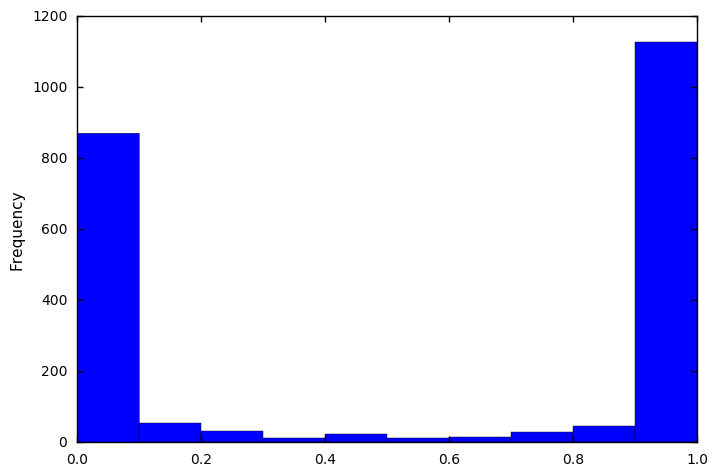

```python
# distribution of F vs M ratio for top 1000 US names
ratio_name['ratio'].plot(kind='hist');
```

We put everything in a function so that we can process French data.

```python
# plot distribution of F vs M ratio for top 1000 names
def plot_distribution(df):
    top_names = df.groupby('name').sum()['births']
    top_names = top_names.sort_values(ascending=False)
    top_names = top_names[top_names >= 10000]
    selection = df[df['name'].isin(top_names.index)]
    ratio_name = selection.pivot_table(index=['name'],
                                         columns='gender',
                                         values='births',
                                         aggfunc=np.sum)
    ratio_name["ratio"] = ratio_name["F"] / (ratio_name["F"] + ratio_name["M"])
    ratio_name['ratio'].plot(kind='hist');
```

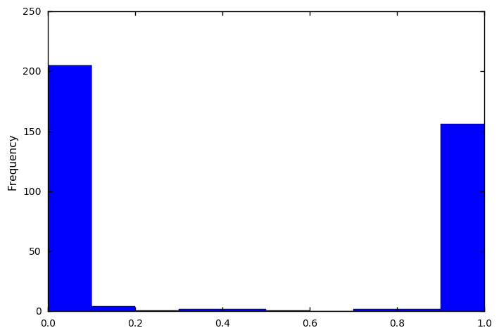

```python
# distribution of F vs M ratio for top 1000 French names
plot_distribution(fr)
```

### 6.2 Plot evolution of names which gender changed over years

First we select the data related to a single name, for instance *Leslie*.

```python
# select US data for Leslie
selection = us[us["name"] == "Leslie"]
selection
```

|  | year | name | gender | births | last |
| --- | --- | --- | --- | --- | --- |
| 654 | 1880 | Leslie | F | 8 | E |
| 1108 | 1880 | Leslie | M | 79 | E |
| 2522 | 1881 | Leslie | F | 11 | E |
| 3072 | 1881 | Leslie | M | 92 | E |
| 4593 | 1882 | Leslie | F | 9 | E |
| 5081 | 1882 | Leslie | M | 122 | E |
| 6850 | 1883 | Leslie | F | 7 | E |
| 7225 | 1883 | Leslie | M | 120 | E |
| ... | ... | ... | ... | ... | ... |
| 1759787 | 2013 | Leslie | F | 1111 | E |
| 1781819 | 2013 | Leslie | M | 36 | E |
| 1793093 | 2014 | Leslie | F | 1000 | E |
| 1814143 | 2014 | Leslie | M | 61 | E |
| 1826333 | 2015 | Leslie | F | 878 | E |
| 1847409 | 2015 | Leslie | M | 54 | E |
| 1859438 | 2016 | Leslie | F | 801 | E |
| 1880467 | 2016 | Leslie | M | 45 | E |

274 rows × 5 columns

Then we compute the evolution of births for this name by gender over years. Note that we could have reuse the selection performed above in *ratio_gender*.

```python
# evolution of births by gender
evolution_gender = selection.pivot_table(index='year',
                                         columns='gender',
                                         values='births')
evolution_gender
```

| gender year | F | M |
| --- | --- | --- |
| 1880 | 8 | 79 |
| 1881 | 11 | 92 |
| 1882 | 9 | 122 |
| 1883 | 7 | 120 |
| 1884 | 15 | 125 |
| 1885 | 10 | 122 |
| 1886 | 8 | 136 |
| 1887 | 12 | 166 |
| ... | ... | ... |
| 2009 | 1981 | 76 |
| 2010 | 1564 | 47 |
| 2011 | 1285 | 54 |
| 2012 | 1220 | 50 |
| 2013 | 1111 | 36 |
| 2014 | 1000 | 61 |
| 2015 | 878 | 54 |
| 2016 | 801 | 45 |

137 rows × 2 columns

Then we compute the F and M ratio by dividing the births by the sum of each line (*axis=1*) along the index (*axis=0*).

```python
# gender evolution over years
evolution_gender = evolution_gender.div(evolution_gender.sum(axis=1), axis=0)
evolution_gender
```

| gender year | F | M |
| --- | --- | --- |
| 1880 | 0.092 | 0.908 |
| 1881 | 0.107 | 0.893 |
| 1882 | 0.069 | 0.931 |
| 1883 | 0.055 | 0.945 |
| 1884 | 0.107 | 0.893 |
| 1885 | 0.076 | 0.924 |
| 1886 | 0.056 | 0.944 |
| 1887 | 0.067 | 0.933 |
| ... | ... | ... |
| 2009 | 0.963 | 0.037 |
| 2010 | 0.971 | 0.029 |
| 2011 | 0.960 | 0.040 |
| 2012 | 0.961 | 0.039 |
| 2013 | 0.969 | 0.031 |
| 2014 | 0.943 | 0.057 |
| 2015 | 0.942 | 0.058 |
| 2016 | 0.947 | 0.053 |

137 rows × 2 columns

Put everything in a function and run over US and French data.

```python
# plot gender ratio evolution of years
def plot_transname(df, name):
    selection = df[df["name"] == name]
    gender = selection.pivot_table(index='year',
                                   columns='gender',
                                   values='births')
    gender = gender.div(gender.sum(axis=1), axis=0)
    gender.plot(title="Evolution proportion of {} by gender over years".format(name), style={'M': 'b', 'F': 'r'});
```

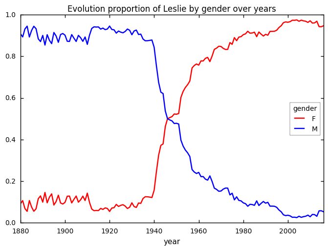

```python
# gender evolution of US Donnie
plot_transname(us, "Leslie")
```

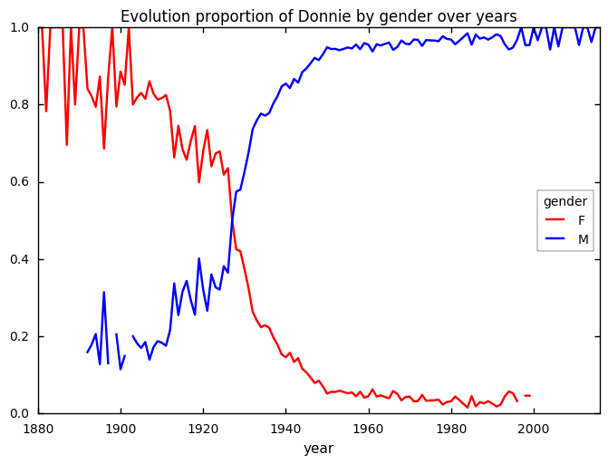

```python
# gender evolution of US Donnie
plot_transname(us, "Donnie")
```

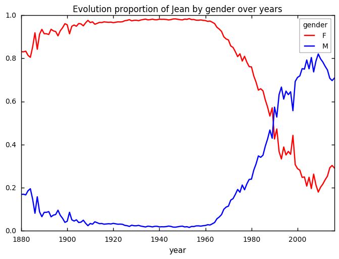

```python
plot_transname(us, 'Jean')
```

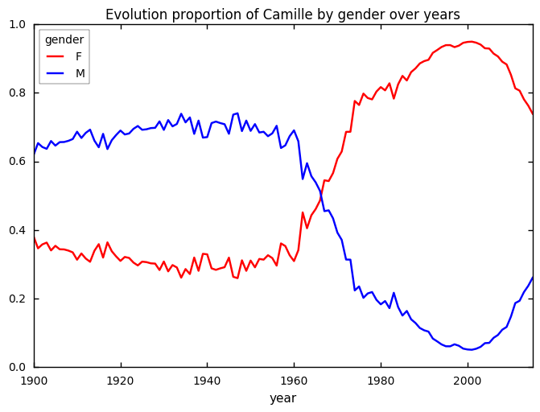

```python
# gender evolution of French Camille
plot_transname(fr, "Camille")
```

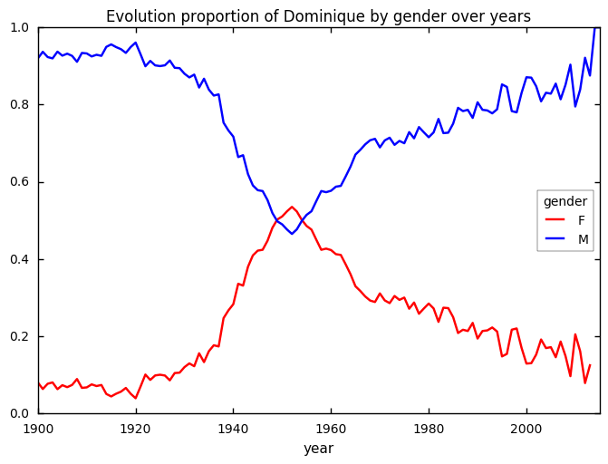

```python
# gender evolution of French Dominique
plot_transname(fr, "Dominique")
```

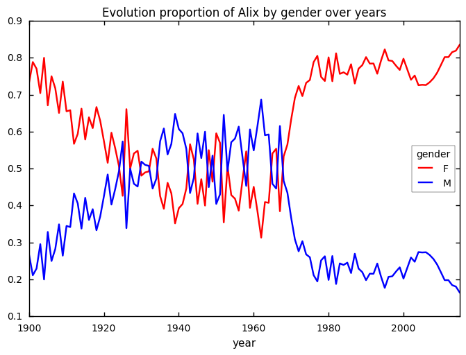

```python
# gender evolution of French Alix
plot_transname(fr, "Alix")
```

## 7. Few cross analysis

### 7.1 Names with different genders in US and France

First, we partly reuse the *plot_distribution()* function to get the F vs M ratio for top 1000 names.

```python
# add a ratio F vs M for top 1000 names
def ratio(df):
    top1000 = df.groupby('name').sum()['births']
    top1000 = top1000.sort_values(ascending=False).head(1000)
    selection = df[df['name'].isin(top1000.index)]
    ratio_name = selection.pivot_table(index=['name'],
                                         columns='gender',
                                         values='births',
                                         aggfunc=np.sum)
    ratio_name["ratio"] = ratio_name["F"] / (ratio_name["F"] + ratio_name["M"])
    return ratio_name
```

Second, we concatenate the results to get them in a single DataFrame. We need to rename the columns.

```python
# US and French top 1000 names with F vs M ratio
data = pd.concat([ratio(us), ratio(fr)], axis=1)
data.columns = ['us_F', 'us_M', 'us_ratio', 'fr_F', 'fr_M', 'fr_ratio']
data
```

|  | us_F | us_M | us_ratio | fr_F | fr_M | fr_ratio |
| --- | --- | --- | --- | --- | --- | --- |
| Aaliyah | 79367.0 | 89.0 | 0.999 | NaN | NaN | NaN |
| Aaron | 4269.0 | 568057.0 | 0.007 | NaN | 17337.0 | NaN |
| Abby | 56869.0 | 181.0 | 0.997 | NaN | NaN | NaN |
| Abdelkader | NaN | NaN | NaN | NaN | 9805.0 | NaN |
| Abel | NaN | NaN | NaN | 141.0 | 23293.0 | 0.006 |
| Abigail | 345728.0 | 621.0 | 0.998 | NaN | NaN | NaN |
| Abraham | 203.0 | 86304.0 | 0.002 | NaN | NaN | NaN |
| Achille | NaN | NaN | NaN | 142.0 | 13088.0 | 0.011 |
| ... | ... | ... | ... | ... | ... | ... |
| Yvon | NaN | NaN | NaN | NaN | 40549.0 | NaN |
| Yvonne | 155219.0 | 619.0 | 0.996 | 257058.0 | 3.0 | 1.000 |
| Zachary | 1513.0 | 527858.0 | 0.003 | NaN | NaN | NaN |
| Zakaria | NaN | NaN | NaN | NaN | 9572.0 | NaN |
| Zelie | NaN | NaN | NaN | 7147.0 | NaN | NaN |
| Zoe | 116591.0 | 448.0 | 0.996 | NaN | NaN | NaN |
| Zoey | 71128.0 | 194.0 | 0.997 | NaN | NaN | NaN |
| Zoé | NaN | NaN | NaN | 51220.0 | 311.0 | 0.994 |

1728 rows × 6 columns

Finally, we add a *delta* column with the absolute difference between US and French ratio and we sort the DataFrame.

```python
# compute ratio absolute difference and sort by delta
data["delta"] = np.abs(data["us_ratio"] - data["fr_ratio"])
data.sort_values("delta", ascending=False).head(10)
```

|  | us_F | us_M | us_ratio | fr_F | fr_M | fr_ratio | delta |
| --- | --- | --- | --- | --- | --- | --- | --- |
| Jocelyn | 102306.0 | 351.0 | 0.997 | 11.0 | 1.252e+04 | 8.782e-04 | 0.996 |
| Jean | 457716.0 | 23698.0 | 0.951 | 516.0 | 1.920e+06 | 2.687e-04 | 0.951 |
| Robin | 289143.0 | 44416.0 | 0.867 | 68.0 | 4.450e+04 | 1.526e-03 | 0.865 |
| Joan | 479788.0 | 5973.0 | 0.988 | 1010.0 | 6.193e+03 | 1.402e-01 | 0.847 |
| Alexis | 334514.0 | 62114.0 | 0.843 | 286.0 | 1.445e+05 | 1.975e-03 | 0.841 |
| Morgan | 210534.0 | 41613.0 | 0.835 | 2289.0 | 2.920e+04 | 7.269e-02 | 0.762 |
| Jackie | 90519.0 | 78331.0 | 0.536 | 1415.0 | 1.803e+04 | 7.277e-02 | 0.463 |
| Leslie | 265771.0 | 112643.0 | 0.702 | 15015.0 | 1.380e+02 | 9.909e-01 | 0.289 |
| Dominique | 49958.0 | 22119.0 | 0.693 | 168025.0 | 2.418e+05 | 4.100e-01 | 0.283 |
| Marion | 188109.0 | 71917.0 | 0.723 | 123932.0 | 1.490e+02 | 9.988e-01 | 0.275 |

### 7.2 Correlation between US and French names over time

Here, we try to compute the correlation between US and French names (+ gender) over time. We build 2 Series with births and compute the correlation over 60 years by shifting one Series along the other.

```python
def correlation(us, fr, name, gender):
    # select and pivot US data
    us_name = us[(us['name'] == name) & (us['gender'] == gender)]
    us_name = us_name.pivot_table(index='year', values='births')

    # select and pivot French data
    fr_name = fr[(fr['name'] == name) & (fr['gender'] == gender)]
    fr_name = fr_name.pivot_table(index='year', values='births')

    # get the best correlation over 60 years
    n = 60
    k = int(n / 2) - 1
    results = np.zeros(n)
    for i in range(-k, k + 1):
        results[i + k] = us_name.corr(fr_name.shift(-i))  # French data are shifted negatively
    best = results.argmax()
    print("Correlation over {} years : {:.2f}".format(best - k, results[best]))

    # concatenate and plot data
    data = pd.concat([us_name, fr_name], axis=1)
    data.columns=['us', 'fr']
    data.plot(title="Correlation between US and French {} ({}) over years".format(name, gender), color=['r', 'b'])
```

```
Correlation over 5 years : 0.89
```

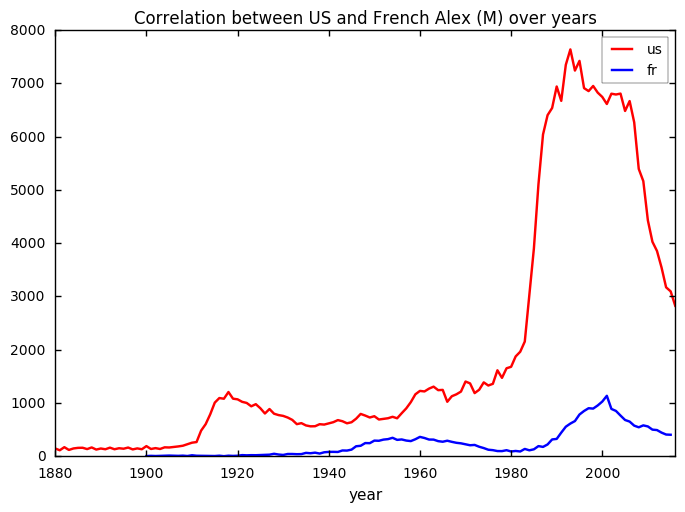

```python
correlation(us, fr, "Alex", "M")
```

```
Correlation over -11 years : 0.91
```

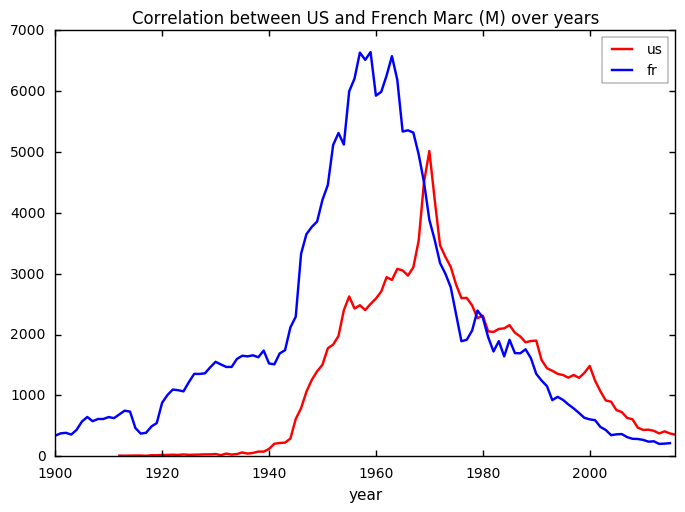

```python
correlation(us, fr, "Marc", "M")
```

```
Correlation over 28 years : 0.98
```

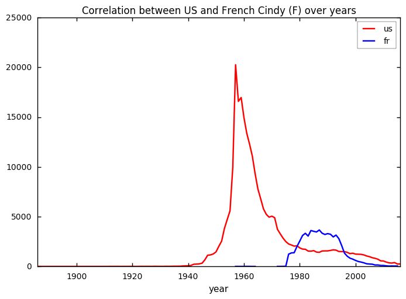

```python
correlation(us, fr, "Cindy", "F")
```

## 8. Conclusion and summary

In this session, we have used some of the powerful Python Data Analysis Ecosystem features.

Links refer to the pandas documentation. Most of the functions and methods we have used provide a number of possible arguments.

**Data representation**

- [Series](https://pandas.pydata.org/pandas-docs/stable/api.html#series): 1D
- [DataFrame](https://pandas.pydata.org/pandas-docs/stable/api.html#dataframe): 2D

**Loading data** with [*read_csv()*](https://pandas.pydata.org/pandas-docs/stable/generated/pandas.read_csv.html)

- header
- names
- sep
- encoding
- converters

**Getting information**

- *index*: Series and DataFrame index
- *columns*: DataFrame column
- *shape*: Series and DataFrame dimensions
- *info()*: DataFrame informations
- *values*: Index and Series values
- *unique()*: Series unique values
- *nunique()*: Series number of unique values

**Selecting data**

- *head()* and *tail()*
- Column accessing
- Row accessing
- Fancy indexing
- Logical masking

**Indexing and merging data**

- [*set_index()*](https://pandas.pydata.org/pandas-docs/stable/generated/pandas.DataFrame.set_index.html) and [*reset_index()*](https://pandas.pydata.org/pandas-docs/stable/generated/pandas.DataFrame.reset_index.html)
- [*append()*](https://pandas.pydata.org/pandas-docs/stable/generated/pandas.DataFrame.append.html) and [*concat()*](http://pandas.pydata.org/pandas-docs/version/0.20/generated/pandas.concat.html)

**Computing over data**

- *sum()*
- *str.len()*, *str.startswith()* and *str.contains()*
- [*apply()*](https://pandas.pydata.org/pandas-docs/stable/generated/pandas.DataFrame.apply.html) and *lambda*
- *isin()*
- *div()*

**Organizing data**

- *transpose()* or *T*
- [*sort_values()*](https://pandas.pydata.org/pandas-docs/stable/generated/pandas.DataFrame.sort_values.html)
- [*groupby()*](https://pandas.pydata.org/pandas-docs/stable/generated/pandas.DataFrame.groupby.html)
- [*pivot_table()*](https://pandas.pydata.org/pandas-docs/stable/generated/pandas.DataFrame.pivot_table.html) and [*crosstab()*](https://pandas.pydata.org/pandas-docs/stable/generated/pandas.crosstab.html)

**Displaying data**

- [*plot()*](https://pandas.pydata.org/pandas-docs/stable/generated/pandas.DataFrame.plot.html)